# Arsenic Buccal DVP

Waverly Wei and Philippe Boileau

## Required Packages

```r
library(tidyverse)
library(knitr)
library(minfi)
library(limma)
library(IlluminaHumanMethylationEPICanno.ilm10b4.hg19)
library(DMRcate)
library(doParallel)
library(GenomicFeatures)
library(org.Hs.eg.db)
library(missMethyl)
library(omicsPrint)
library(kableExtra)

# call helpers
source("../helper-scripts/DVP-utility-functions.R")
source("../helper-scripts/plotting-functions.R")
source("../helper-scripts/probe-annotation.R")
source("../helper-scripts/shared-helpers.R")

# knitr settings
knitr::opts_chunk$set(echo = TRUE, warning = FALSE, message = FALSE)
```

## Load Data

```r
# Load Data
load(
  "../../arsenic-epigenetics-meta/Chile/buccal/data/buccal_funnorm_data.RData"
)

pheno <- as.data.frame(pheno)

# load ReFACTor output, join with pheno
refactor_components <- read_tsv(
  "preprocessing-reports/refactor_buccal.out.components.txt",
  col_names = FALSE
)
colnames(refactor_components) <- paste0("refactor", seq_len(6))
pheno <- cbind(pheno, refactor_components)
```

## Exposure Counts

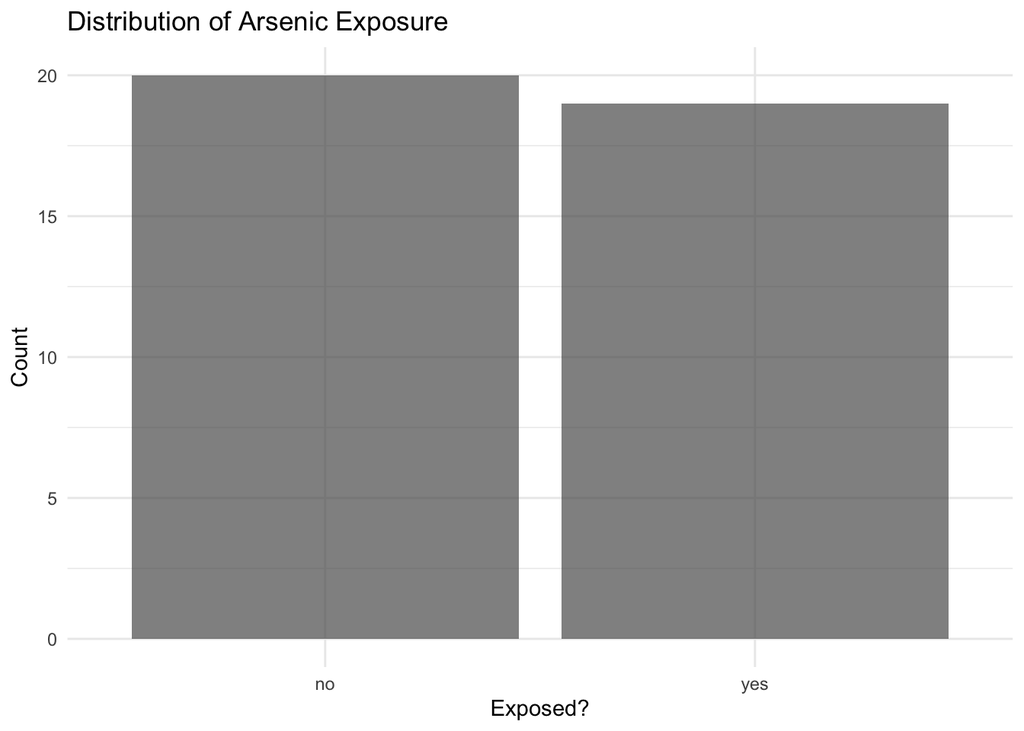

```r
exp_dist_p
```

## Fit Models

```r
# Unadjusted model matrix
modUnadj <- model.matrix(~pheno$exposed)

# Adjusted for cell type
modCell <- model.matrix(~pheno$exposed + pheno$refactor1 + pheno$refactor2 +
                        pheno$refactor3 + pheno$refactor4 + pheno$refactor5 +
                        pheno$refactor6)

# Adjusted for age, smoking, and sex
modAgeSMSex <- model.matrix(~pheno$exposed + pheno$age + pheno$smoking +
                            pheno$sex)

# Adjusted for age, smoking, sex, anc cell composition
modCellAgeSMSex <- model.matrix(~pheno$exposed + pheno$age + pheno$smoking +
                                pheno$sex + pheno$refactor1 + pheno$refactor2 +
                                pheno$refactor3 + pheno$refactor4 +
                                pheno$refactor5 + pheno$refactor6)

# Run DVP function
DVP_u <- run_DVP(mvals = mvals_fun, design = modUnadj)
DVP_cell <- run_DVP(mvals = mvals_fun, design = modCell)
DVP_ageSmSex <- run_DVP(mvals = mvals_fun, design = modAgeSMSex)
DVP_cellAgeSmSex <- run_DVP(mvals = mvals_fun, design = modCellAgeSMSex)
```

## DVP Results

The results are compilued using the Bonferroni correction, but we would be better off using Holm’s procedure. It is uniformely more powerful than the Bonferroni correction.

```r
# Unadjusted model ##########

# filter by p values
table(DVP_u$P.Value < 0.05)
```

```
##
##  FALSE   TRUE
## 677091  51121
```

```r
# filter by BH-adjusted-pvalues
table(DVP_u$Adj.P.Value < 0.05)
```

```
##
##  FALSE   TRUE
## 728206      6
```

```r
# filter by Bonferroni-adjusted pvalues
table(DVP_u$Bonferroni < 0.05)
```

```
##
##  FALSE   TRUE
## 728208      4
```

```r
# save results
write.table(
  DVP_u,
  file = "DVP-results/unadjusted.txt",
  sep = "\t",
  row.names = FALSE,
  col.names = TRUE
)

# Adjusted for cell ##########

# filter by p values
table(DVP_cell$P.Value < 0.05)
```

```
##
##  FALSE   TRUE
## 680080  48132
```

```r
# filter by BH-adjusted-pvalues
table(DVP_cell$Adj.P.Value < 0.05)
```

```
##
##  FALSE   TRUE
## 728201     11
```

```r
# filter by Bonferroni-adjusted pvalues
table(DVP_cell$Bonferroni < 0.05)
```

```
##
##  FALSE   TRUE
## 728207      5
```

```r
# save results
write.table(
  DVP_cell,
  file = "DVP-results/cell.txt",
  sep = "\t",
  row.names = FALSE,
  col.names = TRUE
)

# Adjusted for age, sex, and smoking status

# filter by p values
table(DVP_ageSmSex$P.Value < 0.05)
```

```
##
##  FALSE   TRUE
## 692081  36131
```

```r
# filter by BH-adjusted-pvalues
table(DVP_ageSmSex$Adj.P.Value < 0.05)
```

```
##
##  FALSE   TRUE
## 728207      5
```

```r
# filter by Bonferroni-adjusted pvalues
table(DVP_ageSmSex$Bonferroni < 0.05)
```

```
##
##  FALSE   TRUE
## 728208      4
```

```r
# save results
write.table(
  DVP_ageSmSex,
  file = "DVP-results/age-sex-smoking.txt",
  sep = "\t",
  row.names = FALSE,
  col.names = TRUE
)

# Adjusted for cell, age, sex, and smoking status

# filter by p values
table(DVP_cellAgeSmSex$P.Value < 0.05)
```

```
##
##  FALSE   TRUE
## 692284  35928
```

```r
# filter by BH-adjusted-pvalues
table(DVP_cellAgeSmSex$Adj.P.Value < 0.05)
```

```
##
##  FALSE   TRUE
## 728205      7
```

```r
# filter by Bonferroni-adjusted pvalues
table(DVP_cellAgeSmSex$Bonferroni < 0.05)
```

```
##
##  FALSE   TRUE
## 728208      4
```

```r
# save results
write.table(
  DVP_cellAgeSmSex,
  file = "DVP-results/cell-age-sex-smoking.txt",
  sep = "\t",
  row.names = FALSE,
  col.names = TRUE
)
```

## Annotate Probes

We now annotate the probes that are significant (after the Bonferroni correction) in the full model.

### Full Model

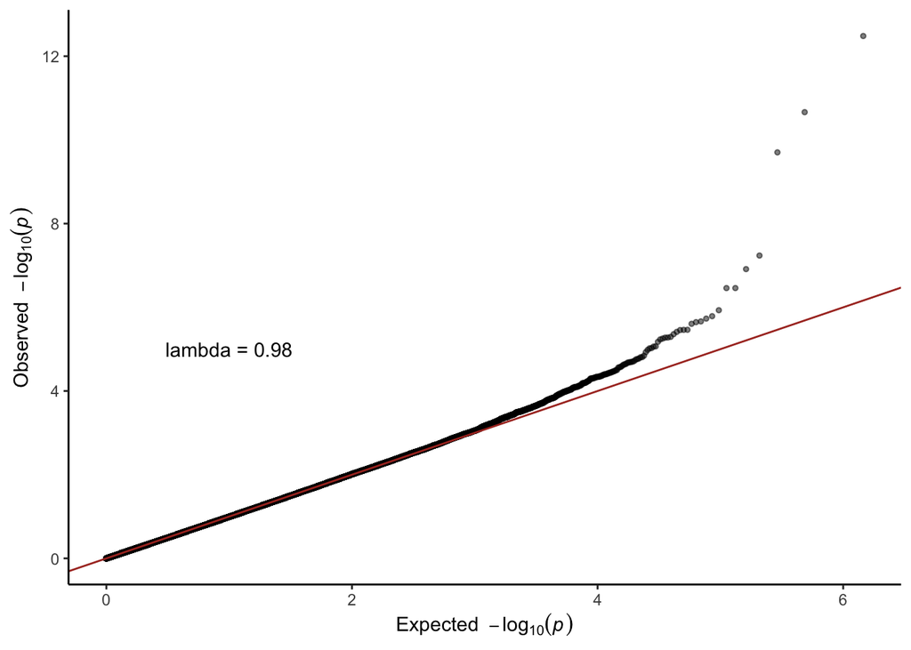

```r
gg_qqplot(DVP_cellAgeSmSex$P.Value)
```

```r
# full model only
DVP_sig <- DVP_cellAgeSmSex %>%
  filter(Bonferroni < 0.05)

DVP_annot <- annotate_probes(probeID_column = 1, DVP_sig)

data(hm450.manifest.pop.GoNL)
dat <- data.frame(hm450.manifest.pop.GoNL)
rownames(dat) <- names(hm450.manifest.pop.GoNL)
maskname <- rownames(dat)[
  which(dat[, paste("MASK.general.", "EAS", sep = "")] == TRUE)]

DVP_CpG <- DVP_annot$Probe_ID
length(unique(DVP_CpG[(DVP_CpG %in% maskname)]))
```

```
## [1] 0
```

```r
DVP_annot <- DVP_annot[!(DVP_annot$Probe_ID %in% maskname), ]
bonf <- dplyr::filter(DVP_annot, Bonferroni < 0.05)
DVP_bonf <- bonf$Probe_ID
length(unique(DVP_bonf[(DVP_bonf %in% maskname)]))
```

```
## [1] 0
```

```r
DVP_annot <- DVP_annot %>% arrange(Bonferroni)
```

```r
DVP_annot %>%
  kbl() %>%
  kable_styling() %>%
  scroll_box(width = "100%", height = "300px")
```

Probe_ID

cpg

SampleVar

LogVarRatio

DiffLevene

t

P.Value

Adj.P.Value

Bonferroni

std_err

chr

pos

strand

UCSC_RefGene_Group

Phantom4_Enhancers

Phantom5_Enhancers

DMR

X450k_Enhancer

HMM_Island

Regulatory_Feature_Name

Regulatory_Feature_Group

GencodeBasicV12_NAME

GencodeBasicV12_Accession

SNP_ID

SNP_DISTANCE

SNP_MinorAlleleFrequency

Islands_Name

cg14685237

cg14685237

1.4793200

4.325901

1.271909

8.535346

0e+00

0.0000002

0.0000002

0.1497991

chr8

129659734

chr8:129659601-129659601

rs139890189;rs11994743;rs10956433

0;1;30

0.004992;0.003994;0.203674

cg07770866

cg07770866

2.5419440

3.775977

1.719266

8.275825

0e+00

0.0000079

0.0000158

0.2377233

chr8

121821052

Body

8:121820605-121821494

Promoter_Associated

SNTB1

ENST00000519177.1

rs189234972;rs143508851;rs550504284

28;17;13

0.000200;0.000399;0.000399

chr8:121823534-121824720

cg00579468

cg00579468

1.5453685

-1.688895

-1.211149

-7.178011

0e+00

0.0000482

0.0001445

0.1716367

chr7

129647468

RP11-306G20.1

ENST00000480018.1

rs10265866;rs145419171;rs10954256;rs545892134

15;16;17;43

0.048123;0.008786;0.444089;0.000200

cg03400443

cg03400443

0.3506537

-2.783309

-0.606351

-5.921392

1e-07

0.0105607

0.0422429

0.1107401

chr2

74347616

high-CpG:74200956-74201324

2:74200782-74201251

2:74346472-74348474

Unclassified

rs563814250;rs192268634;rs56095668;rs564624088;rs1667618

6;31;45;46;50

0.000399;0.000399;0.014776;0.000200;0.213758

chr2:74347273-74347777

### Almost Full Model (No Cells)

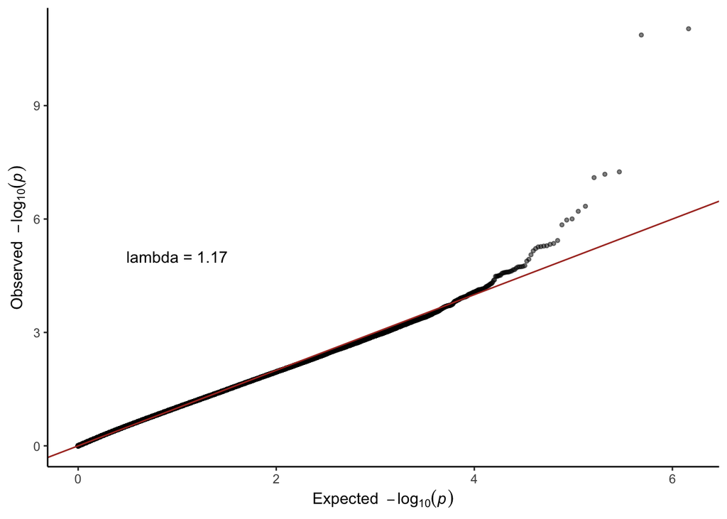

```r
gg_qqplot(DVP_ageSmSex$P.Value)
```

```r
# full model
DVP_sig <- DVP_ageSmSex %>%
  filter(Bonferroni < 0.05)

DVP_annot <- annotate_probes(probeID_column = 1, DVP_sig)
DVP_CpG <- DVP_annot$Probe_ID
length(unique(DVP_CpG[(DVP_CpG %in% maskname)]))
```

```
## [1] 0
```

```r
DVP_annot <- DVP_annot[!(DVP_annot$Probe_ID %in% maskname), ]
bonf <- dplyr::filter(DVP_annot, Bonferroni < 0.05)
DVP_bonf <- bonf$Probe_ID
length(unique(DVP_bonf[(DVP_bonf %in% maskname)]))
```

```
## [1] 0
```

```r
DVP_annot <- DVP_annot %>% arrange(Bonferroni)
```

```r
DVP_annot %>%
  kbl() %>%
  kable_styling() %>%
  scroll_box(width = "100%", height = "300px")
```

Probe_ID

cpg

SampleVar

LogVarRatio

DiffLevene

t

P.Value

Adj.P.Value

Bonferroni

std_err

chr

pos

strand

UCSC_RefGene_Group

Phantom4_Enhancers

Phantom5_Enhancers

DMR

X450k_Enhancer

HMM_Island

Regulatory_Feature_Name

Regulatory_Feature_Group

GencodeBasicV12_NAME

GencodeBasicV12_Accession

SNP_ID

SNP_DISTANCE

SNP_MinorAlleleFrequency

Islands_Name

cg14685237

cg14685237

1.4793200

4.325901

1.2855558

7.787325

0e+00

0.0000049

0.0000067

0.1490776

chr8

129659734

chr8:129659601-129659601

rs139890189;rs11994743;rs10956433

0;1;30

0.004992;0.003994;0.203674

cg07770866

cg07770866

2.5419440

3.775977

1.6882754

7.707974

0e+00

0.0000049

0.0000099

0.2239965

chr8

121821052

Body

8:121820605-121821494

Promoter_Associated

SNTB1

ENST00000519177.1

rs189234972;rs143508851;rs550504284

28;17;13

0.000200;0.000399;0.000399

chr8:121823534-121824720

cg00717648

cg00717648

0.2603285

-3.653254

-0.5502163

-5.906232

1e-07

0.0116958

0.0411367

0.0958463

chr5

43041489

Body;TSS1500;TSS1500

TRUE

5:43041392-43041650

Promoter_Associated

AC025171.1;ANXA2R

ENST00000451894.2;ENST00000314890.3

rs150900952;rs139479003

22;49

0.000399;0.006789

chr5:43040345-43040633

cg00579468

cg00579468

1.5453685

-1.688895

-1.1365118

-5.873015

1e-07

0.0116958

0.0476237

0.1739447

chr7

129647468

RP11-306G20.1

ENST00000480018.1

rs10265866;rs145419171;rs10954256;rs545892134

15;16;17;43

0.048123;0.008786;0.444089;0.000200